# Core Elements of Programs

Lecture 2

Author

Piero Palacios

Published

March 5, 2024

## Variables (Revisited)

- name
  - descriptive
  - meaningful
  - helps you re-read the code
  - cannot be keywords
- value
  - information stored
  - can be updated

“=” is called assignment.

```r
x = 2
x = x*x
y = x + 1
```

Is this ok? No.

```r
x = 1
y = 2
y = x
x = y

x
```

```
[1] 1
```

```r
y
```

```
[1] 1
```

The right way to do it

```r
x = 1
y = 2
temp = y
y = x
x = temp

x
```

```
[1] 2
```

```r
y
```

```
[1] 1
```

## Strings

- String us simple a sequence of characters. Letters, special characters, spaces, digits.
- Enclose in quotation marks or single quotes.

```r
hi = "Hello there"
greetings = 'Hello'

hi
```

```
[1] "Hello there"
```

```r
greetings
```

```
[1] "Hello"
```

### Concatenate strings

```r
name = "Eric"
cat(hi, name, sep=" ")
```

```
Hello there Eric
```

```r
cat(hi,name, sep=",")
```

```
Hello there,Eric
```

```r
greet = paste0(hi,name)
greet
```

```
[1] "Hello thereEric"
```

```r
greeting = paste0(hi," ",name)
greeting
```

```
[1] "Hello there Eric"
```

```r
name2 = strsplit(name,"")
name2
```

```
[[1]]
[1] "E" "r" "i" "c"
```

```r
name2 |>
  class()
```

```
[1] "list"
```

Exercise

```r
# Get "abc" from "a" and "bc"
# Print your full name
```

## Print

The `print` function is important to see the output of variables in programming.

```r
print(name)
```

```
[1] "Eric"
```

```r
print(greeting)
```

```
[1] "Hello there Eric"
```

## `cat`

The `cat` function let you concatenate strings and print with only one command.

```r
cat("How","are","you?")
```

```
How are you?
```

## `readline`

The `readline` function let you interact withthe console and store a value.

```r
x = readline("Give a number:")
```

```
Give a number:
```

```r
y = readline("Give a number:") |>
  as.numeric()
```

```
Give a number:
```

Exercises

```r
if(6>7){
  print("Yep")
}

if(6>7){
  print("Yep")
} else{
  print("Nope")
}

temp = 50

if(temp >85){
  print("Hot")
} else if(temp >100){
  print("Really hot!")
} else if(temp >60){
  print("Comfortable")
} else{
  print("Cold")
}
```

## Control Flow

### Branching Programs (Revisited)

The simplest branching statement is a **conditional**

- A test (expression that evaluates to TRUE or FALSE).
- A block of code to execute if the test is TRUE.
- An optional block of code to execute if the test is FALSE.

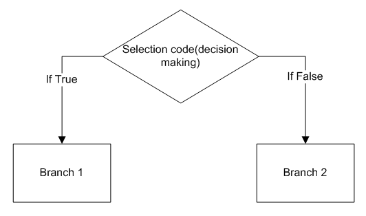

### Comparison operators on int and float (Revisited)

- i and j are any variables:
  - i>j
  - i>=j
  - i<j
  - i<=j
  - i==j -|> equality, True if i equals j
  - i!=j -|> inequality, True if i not equal to j

But, how can we run the code multiple times?

### Using Control in Loops

- Simple branching programs just make choices, but the code still runs linear.
- Sometimes want to reuse parts of the code indeterminate number of times.

For this task we need a loop and there are two types of loops: a while loop and a for loop.

#### `while` Loops

```r
while(<contition>){

  <expression>
  <expression>

}
```

- evaluates to a Boolean.
- if is TRUE, do all the steps inside the while code block.
- check again.
- repeat until is FALSE.

```r
n = 0

while(n != 5){

  string = glue::glue("We are in {n}")
  print(string)
  n = n+1

}
```

```
We are in 0
We are in 1
We are in 2
We are in 3
We are in 4
```

#### `for` Loops

```r
for(i in 0:5){

  print(i)

}
```

```
[1] 0
[1] 1
[1] 2
[1] 3
[1] 4
[1] 5
```

```r
for(<variable> in <range of values>){

  <expression>
  <expression>

}
```

- Each time through the loop, takes a value.
- First time, starts at the smallest value.
- Next time, gets the prev value + 1
- etc.

```r
my_sum = 0

for(i in seq(0,10,by=2)){

  my_sum = my_sum + i

  print(my_sum)

}
```

```
[1] 0
[1] 2
[1] 6
[1] 12
[1] 20
[1] 30
```

#### `break` Statement

- immediately exits whatever loop it is in.
- skips remaining expressions in code block.
- exists only innermost loop.

```r
while(<contition>){

  while(<contition>){

  <expression_a>
  break
  <expression_b>
  }

  <expression_c>
}
```

```r
my_sum = 0

for(i in seq(0,10)){

  my_sum = my_sum + 1

  if(my_sum == 5){
    break
  }

}

print(my_sum)
```

```
[1] 5
```

for vs while loops

| for loops | while loops |
| --- | --- |
| know number of iterations | unbounded number of iterations |
| can end early via break | can end early via break |
| uses a counter | can use a counter but must initialize before the loop and increment it inside the loop |
| can rewrite a for loop using a while loop | may not be able to rewrite a while loop using a for loop |

Exercises

```r
# 1.
numberOfLoops = 0
numberOfApples = 2
while(numberOfLoops < 10){
    numberOfApples = numberOfApples * 2
    numberOfApples = numberOfLoops + numberOfLoops
    numberOfLoops = numberOfLoops + 1
}

print(glue::glue("Number of apples: {numberOfApples}"))

# 2.

num = 10
while(num > 3){
    num = num - 1
    print(num)
}

# 3.

num = 10
while(TRUE){
    if(num < 7){
        print('Breaking out of loop')
        break
    }
    print(num)
    num = num - 1
}

print('Outside of loop')

# 4.

## Convert the following code into code that uses a for loop.

#prints Hello!
# prints 10
# prints 8
# prints 6
# prints 4
# prints 2
```

## Iteration

- Concept of iteration let’s us extend simple branching algorithms to be able to write programs of arbitrary complexity.
  - Start with a test-
  - If evaluates to TRUE, then execute loop body once, and go back to reevaluate the test.
  - Repeat until test evaluates to FALSE, after which code following iteration statement is executed.

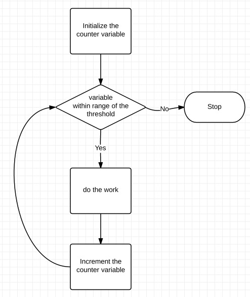

```r
library(glue)
# compute naive power of 2 of a number

x = 3

answer = 0

iters_left = x

while(iters_left != 0){

  answer = answer + x
  iters_left = iters_left - 1

}

print(glue("{x}*{x} = {answer}"))
```

```
3*3 = 9
```

| x | answer | iters_left |
| --- | --- | --- |
| 3 | 0 | 3 |
|  | 3 | 2 |
|  | 6 | 1 |
|  | 9 | 0 |

Some properties of iteration loops: - need to set an iteration variable outside the loop. - need to test variable to determine when done. - need to change variable within the loop, in addition to other work.

### Iterative code

- Branching structures (conditionals) let us jump to different pieces of code based on a test.
- Looping structures (e.g. while) let us repeat pieces of code until a condition is satisfied.

```r
string = "Hola"

string_sequence = strsplit(string,"") |>
  unlist()

for(letter in string_sequence){

  print(letter)

}
```

```
[1] "H"
[1] "o"
[1] "l"
[1] "a"
```

### Classes of Algorithms

- Iterative algorithms allow us to do more complex things than simple arithmetic.
- We can repeat a sequence of steps multiple times based on some decision.

#### Guess and Check

Finding cube root of integer:

```r
# x = readline("Enter an integer: ") |>
#   as.integer()

x = 27

ans = 0

while(ans**3 < x){

  ans = ans + 1

}

if(ans**3 != x){

  print(glue("{x} is not a perfect cube"))

} else {

  print(glue("Cube root of {x} is {ans}"))

}
```

```
Cube root of 27 is 3
```

#### Extending Scope

```r
x = -8

ans = 0

while(ans**3 < abs(x)){

  ans = ans + 1

}

if(ans**3 != abs(x)){

  print(glue("{x} is not a perfect cube"))

} else {

  if(x <0){

    ans = -ans

  }

  print(glue("Cube root of {x} is {ans}"))

}
```

```
Cube root of -8 is -2
```

Useful to think about decrementing function

- Maps set of program variables into an integer.
- When loop is entered, value is non-negative.
- When value is <= 0, loop terminates and
- Value is decreased every time through loop.

A cleaner form

```r
cube = 27

for(guess in seq(0,cube)){

  if((guess^3) == cube){

    glue("Cube root of {cube} is {guess}") |>
      print()

  }

}
```

```
Cube root of 27 is 3
```

```r
cube = -8

for(guess in seq(0,abs(cube))){

  if(guess**3 >= abs(cube)){

    break

  }

}

if(guess**3 != abs(cube)){

  glue("{cube} is not a perfect cube") |>
    print()

} else{

  if(cube < 0){

    guess = -guess

    glue("Cube root of {cube} is {guess}") |>
      print()
  }

}
```

```
Cube root of -8 is -2
```